# JDAC Pulse Survey Results

October 2022

Updated: 2022-11-01

[figure not shown]

## Results and Discussion

### Monthly Questions

#### Wellbeing at Work and in Life

Of the 80 people approached, 44 participated (response rate = 55%) (Fig. 1).

Fig. 1. Participant Demographics (by Team and Grade)

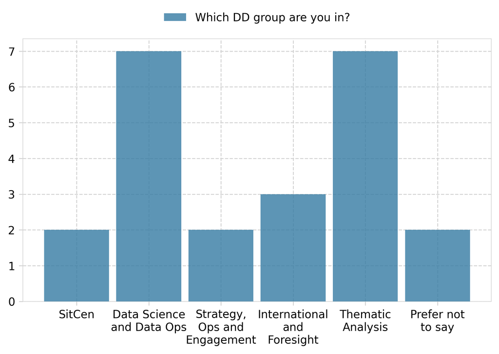

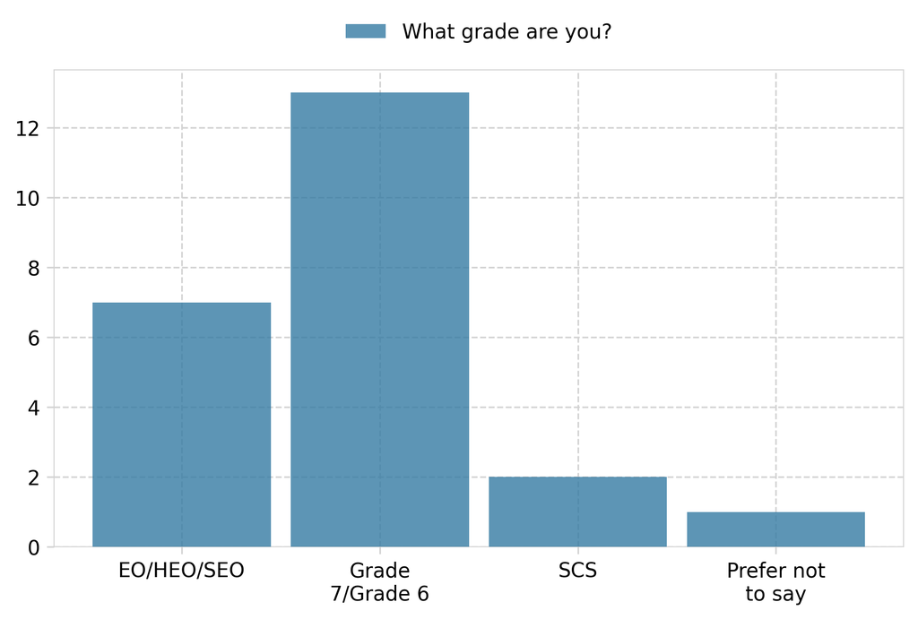

The majority of respondents (77%, 34) expressed they were either ‘in a really good place’ (39%, 17) or ‘in an ok place, but there are things I’d like to improve’ whilst at work respectively (39%, 17) (Fig. 2).

Fig. 2 Wellbeing at Work and in Life

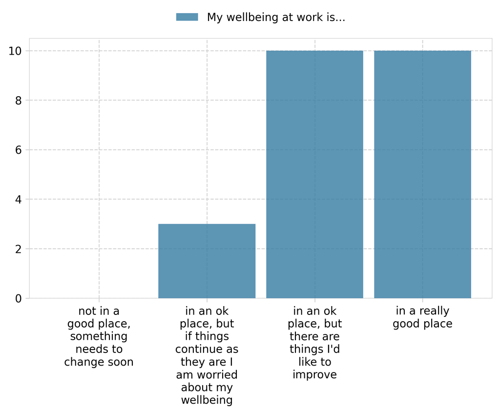

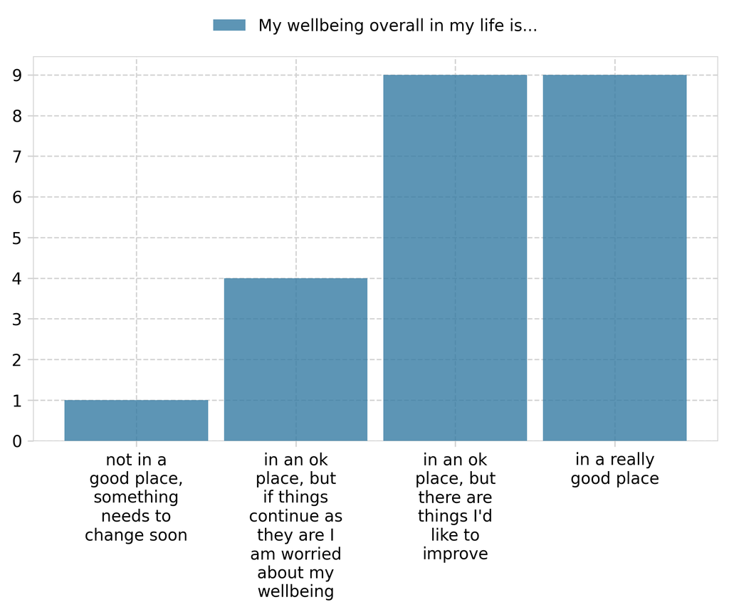

Similarly, most participants (86%, 38) responded that in their personal life, they were either ‘in a really good place’ (39%, 17) or ‘in an ok place, but there things I’d like to improve’ (48%, 21) respectively. Relatively low numbers of respondents across JDAC experienced lower mood at work (7%, 3) or in their personal lives (2%, 1).

#### Workload and Work Fulfillment

The majority of respondents (59%, 26) felt that their workload was ‘just right’ (Fig. 3). However, a considerable proportion of respondents (25%, 11) found that their workload was ‘a bit heavy’ (Fig. 3).

Fig. 3 Workload Feelings

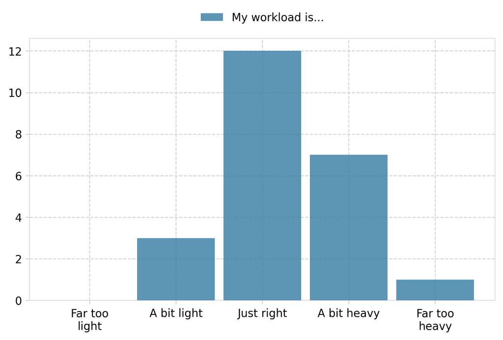

On a scale of 1 to 5, where 1 indicated ‘not at all’ and 5 represented ‘very well’, a median score of 4 was reported for work fulfillment. Most respondents (28) expressed they believed that they their job complemented their interests and skills (Fig. 4).

Fig. 4 Work Fulfillment

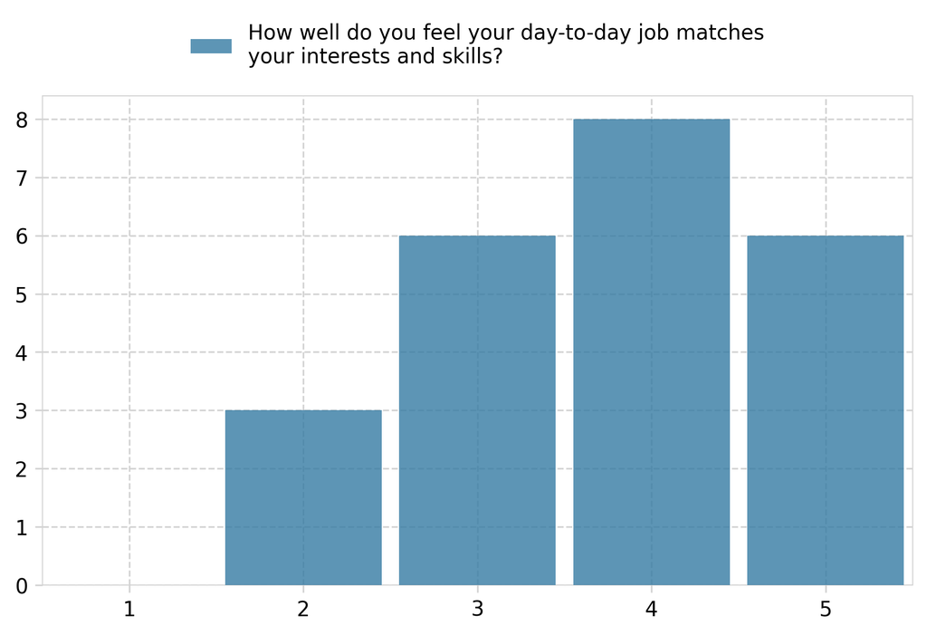

#### Team Effectiveness

The majority of respondents (41%, 18) expressed things were going ‘really well’ in their DD team, ‘quite well’ in JDAC (36%, 16) and ‘ok’ in EDS as a whole (59%, 26) (Fig. 5).

Fig. 5 Team Effectiveness

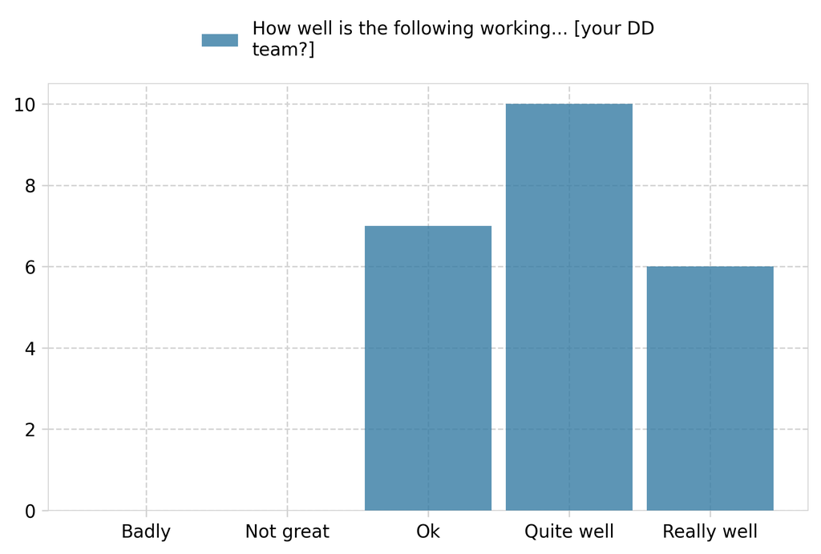

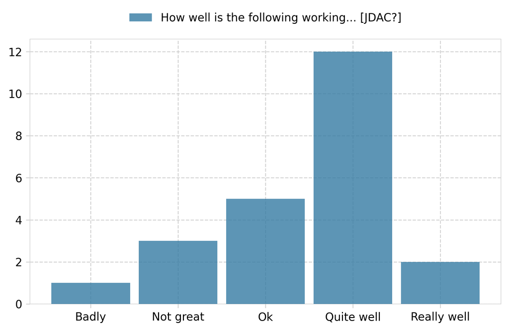

#### Development and Training

The median response of participants reporting they had clearly defined goals was 3 of 5.

Fig. 6 Established Goals

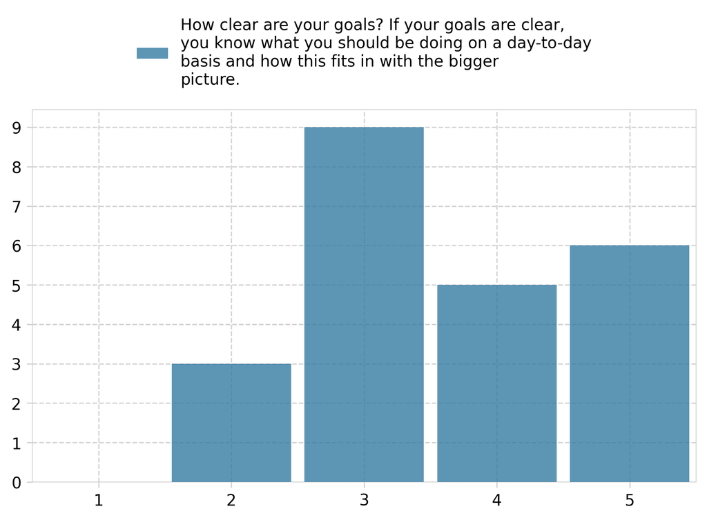

A common theme highlighted by participants included the need for a clearer and unified sense of direction and priorities from the SLT as well as a sense of a common culture across teams to encourage more connection across JDAC.

Fig. 7 Core and Wider Training and Development

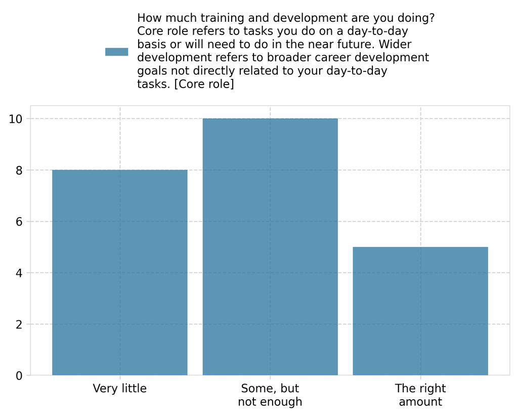

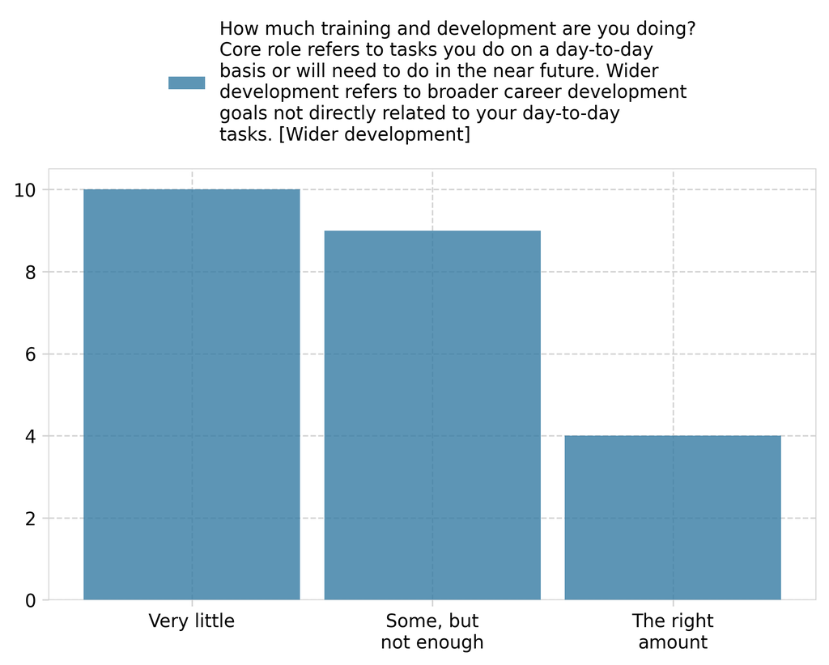

*“How do [the SLT] prioritise learning?”*

### Wildcard Questions

On a scale of 1 to 5, where 1 represented ‘Never’ and 5 represented ‘Always’, most participants across JDAC felt comfortable expressing their opinions in JDAC - the median score of respondents for feeling heard was 4 (Fig. 8).

Fig. 8 I Feel Heard: Comfortability Expressing Opinions

[figure not shown]

Similarly, most respondents across JDAC felt that their opinions were taken into consideration - the median score of respondents for feeling respected was 4 (Fig 9).

Fig. 9 I Feel Respected: My Opinions are Considered

[figure not shown]

Furthermore, many participants felt their contributions to the team were recognised and reported receiving regular feedback on their achievements - the median score of respondents for feeling valued and receiving regular feedback was 4 respectively.

Outside of the listed options featured in the survey, although 43% (17) of participants reported that diverse opinions and perspectives were often involved in other areas/ JDAC as a whole, 43% (17) of respondents disclosed that they felt minoritised groups were less involved in these areas.

Interestingly, respondents highlighted that they found Slido to be the most appropriate method of expressing ideas - the median score was 4 (4-5). All-staff meetings were the least favourite way of expressing opinions - the median score was 3 (2-4). This may indicate that staff require more explicit information or anonymity expressing their ideas about the behaviours they expect in their workspaces, the desire to eliminate ‘grey’ areas and a better experience when sharing their views.

Although this is a self-selecting sample which may consist of low numbers of participants from minoritised communities, it may still provide a good idea of how staff currently feel across JDAC.

Fig. 10 Training and Development Planning

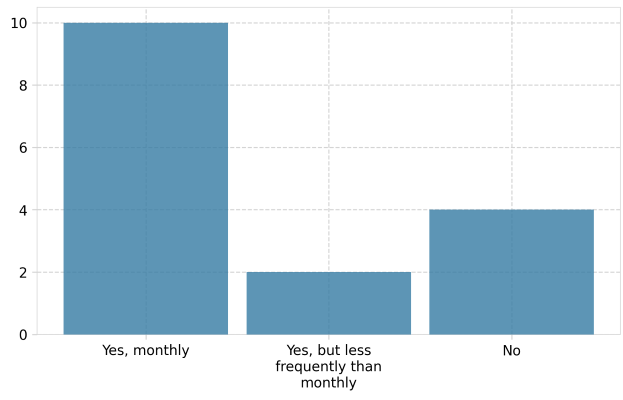

## Methodology

Each item in the survey was reviewed within the JDAC Pulse Survey Strand so the relevance and appropriateness could be discussed. A pilot test conducted during a Senior Management Team meeting asked volunteers to verbally evaluate items that were not understood. No difficulties were encountered. Minor changes were made to the questions in the final version following the pilot.

The survey consisted of 20 questions and six sections (please refer to Table 1).

| Section | No. of Items | Type of Data | Response Options | Additional Response Options 1 | Additional Response Options 2 | Additional Response Options 3 | Additional Response Options 4 | Additional Response Options 5 | Additional Response Options 6 |
| --- | --- | --- | --- | --- | --- | --- | --- | --- | --- |
| Monthly Questions | 11 | Nominal Scale; Frequency Scale; Semantic Differential Scale; 3-point Likert Scale; 5-point Likert Scale | 1 = not in a good place, something needs to change soon; 2 = in an ok place, but if things continue as they are I am worried about my wellbeing; 3 = in an ok place, but there are things I'd like to im… | 1 = not in a good place, something needs to change soon; 2 = in an ok place, but if things continue as they are I am worried about my wellbeing; 3 = in an ok place, but there are things I'd like to im… | 1 = Far too light; 2 = A bit light; 3 = Just right; 4 = A bit heavy; Far too heavy | 1 = Not at all; 5 = Very well | 1 = Badly; 2 = Not great; 3 = Ok; 4 = Quite well; 5 = Really well | 1 = Very unclear; 5 = Very clear | 1 = Very little; 2 = Some, but not enough; 3 = The right amount |
| Wildcard Question: The Mid-Year Review | 1 | Nominal Scale |  |  |  |  |  |  |  |
| I Have Completed My Mid-Year Review | 3 | Semantic Differential Scale | 1 = Very unhappy; 5 = Very happy | 1 = Very satisfied; 5 = Very satisfied |  |  |  |  |  |
| I Have Not Completed My Mid-Year Review (please skip this section if you have completed a review or are exempt) | 3 | Semantic Differential Scale; Nominal Scale | 1 = Not at all - I have no idea how it works; 5 = Very well - I know exactly what the process is | 1 = Not at all prepared; 5 = Very prepared |  |  |  |  |  |
| I Am Exempt From Doing a Mid-Year Review | 1 | Nominal Scale |  |  |  |  |  |  |  |
| Further Information | 1 |  |  |  |  |  |  |  |  |

Participants who had not responded were contacted via email, team meetings and/ or the group chat and reminded to complete their survey weekly. Data was analysed using RStudio 2022.07.1+554.

## Supplementary Material

### Charts

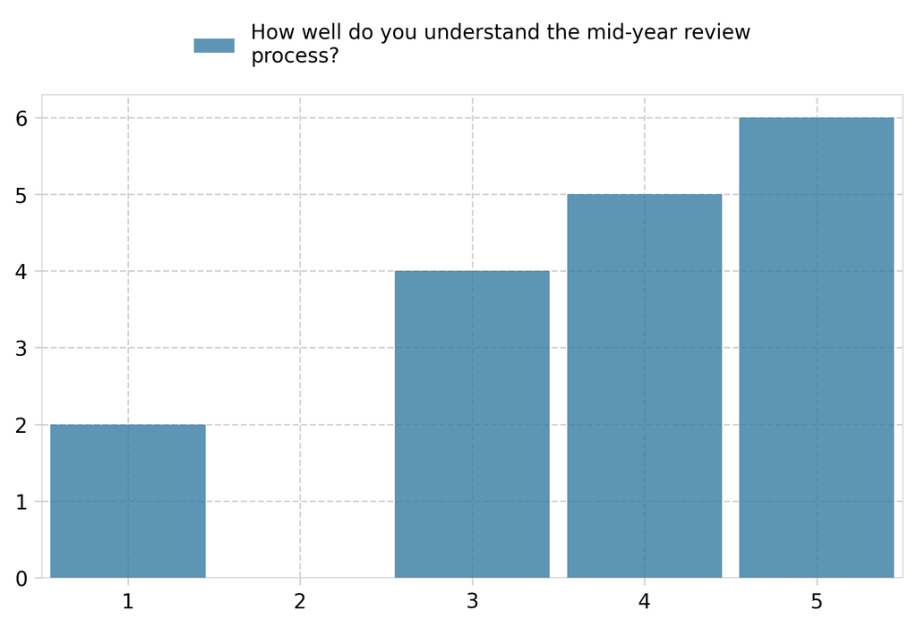

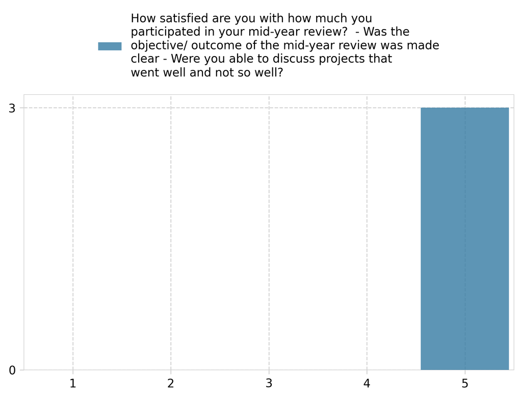

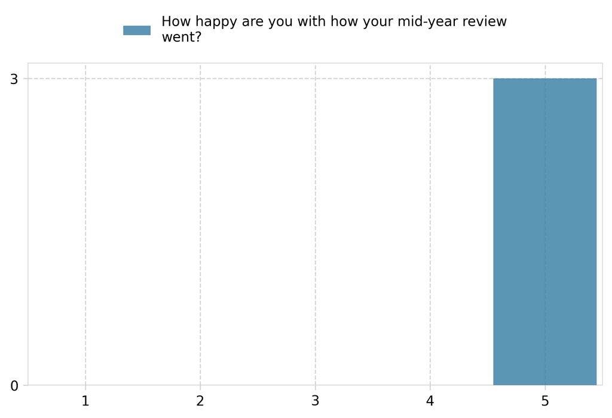

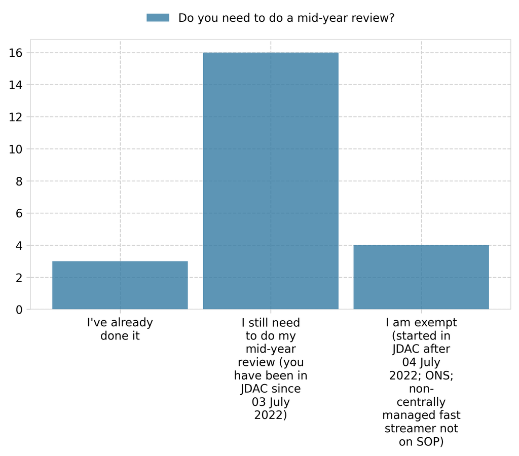

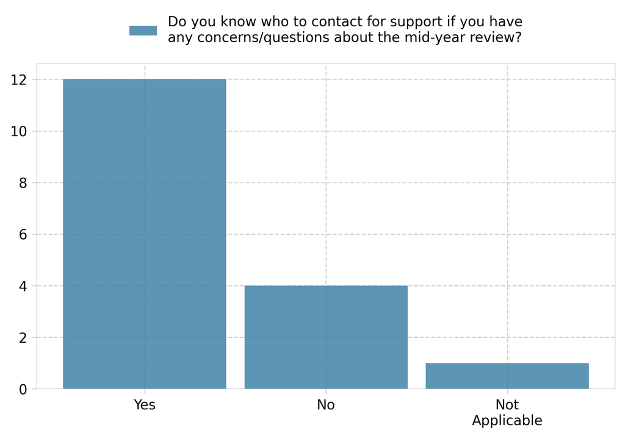

### Tables

Table 2. Wellbeing at Work and in Life

| **Characteristic** | **N = 44**<sup>1</sup> |
| --- | --- |
| Wellbeing at Work |  |
| in a really good place | 17 (38.6) |
| in an ok place, but if things continue as they are I am worried about my wellbeing | 7 (15.9) |
| in an ok place, but there are things I'd like to improve | 17 (38.6) |
| not in a good place, something needs to change soon | 3 (6.8) |
| Wellbeing in Life |  |
| in a really good place | 17 (38.6) |
| in an ok place, but if things continue as they are I am worried about my wellbeing | 5 (11.4) |
| in an ok place, but there are things I'd like to improve | 21 (47.7) |
| not in a good place, something needs to change soon | 1 (2.3) |

Source: Internal data  
<sup>1</sup> n (%)

Table 3. Workload and Work Fulfillment

| **Characteristic** | **N = 44**<sup>1</sup> |
| --- | --- |
| Workload Feelings |  |
| A bit heavy | 11 (25.0) |
| A bit light | 5 (11.4) |
| Far too heavy | 2 (4.5) |
| Just right | 26 (59.1) |
| Work Fulfillment | 4.0 (3.0, 4.2) |

Source: Internal data  
<sup>1</sup> n (%); Median (IQR)

Table 4. Team Effectiveness

| **Characteristic** | **N = 44**<sup>1</sup> |
| --- | --- |
| Team Effectiveness: DD |  |
| Not great | 1 (2.3) |
| Ok | 10 (22.7) |
| Quite well | 15 (34.1) |
| Really well | 18 (40.9) |
| Team Effectiveness: JDAC |  |
| Badly | 1 (2.3) |
| Not great | 6 (13.6) |
| Ok | 14 (31.8) |
| Quite well | 16 (36.4) |
| Really well | 7 (15.9) |
| Team Effectiveness: EDS |  |
| Badly | 5 (11.4) |
| Not great | 10 (22.7) |
| Ok | 26 (59.1) |
| Quite well | 3 (6.8) |

Source: Internal data  
<sup>1</sup> n (%)

Table 5. Development and Training

| **Characteristic** | **N = 23**<sup>1</sup> |
| --- | --- |
| Established Goals | 3.0 (3.0, 4.5) |
| Core Training and Development |  |
| Some, but not enough | 10 (43.5) |
| The right amount | 5 (21.7) |
| Very little | 8 (34.8) |
| Wider Training and Development |  |
| Some, but not enough | 9 (39.1) |
| The right amount | 4 (17.4) |
| Very little | 10 (43.5) |

Source: Internal data  
<sup>1</sup> Median (IQR); n (%)

Table 6. Diversity and Inclusion: Respect, Value and Feedback

| **Characteristic** | **N = 44**<sup>1</sup> |
| --- | --- |
| I Feel Heard: I am Comfortable Expressing Opinions | 4.0 (4.0, 5.0) |
| I Feel Respected: My Opinions are Considered | 4.0 (3.0, 5.0) |
| Regular Feedback: My Work and Contributions | 4.0 (3.0, 4.0) |
| I Feel Valued: My Contributions are Recognised | 4.0 (3.8, 4.2) |

Source: Internal data  
<sup>1</sup> Median (IQR)

Table 7. Diversity and Inclusion: Operational Decisions

| **Characteristic** | **N = 44**<sup>1</sup> |
| --- | --- |
| Diverse Opinions and Perspectives: Data Choice |  |
| Always | 4 (9.1) |
| Often | 18 (40.9) |
| Rarely | 10 (22.7) |
| Sometimes | 12 (27.3) |
| Diverse Opinions and Perspectives: Collaboration |  |
| Always | 3 (6.8) |
| Often | 21 (47.7) |
| Rarely | 4 (9.1) |
| Sometimes | 16 (36.4) |
| Diverse Opinions and Perspectives: Recruitment |  |
| Always | 4 (9.3) |
| Never | 1 (2.3) |
| Often | 21 (48.8) |
| Rarely | 8 (18.6) |
| Sometimes | 9 (20.9) |
| Unknown | 1 |
| Diverse Opinions and Perspectives: Change |  |
| Always | 2 (4.5) |
| Never | 2 (4.5) |
| Often | 18 (40.9) |
| Rarely | 11 (25.0) |
| Sometimes | 11 (25.0) |
| Diverse Opinions and Perspectives: Any Other Areas |  |
| Always | 1 (2.5) |
| Often | 17 (42.5) |
| Rarely | 5 (12.5) |
| Sometimes | 17 (42.5) |
| Unknown | 4 |

Source: Internal data  
<sup>1</sup> n (%)

Table 8. Diversity and Inclusion: Different Methods of Expressing Perspectives

| **Characteristic** | **N = 44**<sup>1</sup> |
| --- | --- |
| Expressing Perspectives: Slido | 4.0 (4.0, 5.0) |
| Unknown | 2 |
| Expressing Perspectives: Google Forms | 4.0 (3.0, 5.0) |
| Unknown | 1 |
| Expressing Perspectives: All-Staff Meetings | 3.0 (2.0, 4.0) |
| Unknown | 1 |
| Expressing Perspectives: Small Meetings | 4.0 (3.0, 5.0) |
| Unknown | 1 |
| Expressing Perspectives: 1-to-1 with a DD | 4.0 (3.2, 5.0) |
| Unknown | 2 |

Source: Internal data  
<sup>1</sup> Median (IQR)